# REPORT OUT: Sport Statistics

#### SECTION 1: Questions To Answer

- **Q1: Is there any correlation between the performance of a country in winter Olympics and that in summer Olympics?**

  > Answering this question could help identify whether countries that perform well in one type of Olympics (summer or winter) tend to perform well in the other as well. This could highlight countries with versatile athletic programs and training systems.
- **Q2: Does performance change with age?**

  > Analyzing how the age of athletes correlates with their performance (measured by medals won) could reveal patterns in the age at which athletes tend to excel in various sports. This might indicate optimal age ranges for peak performance in different disciplines.
- **Q3: How has the male:female ratio evolved through time?**

  > Studying the historical trends in the male-to-female ratio of athletes over different Olympic games could provide insights into gender equality and representation in sports. It might indicate changes in societal attitudes towards women in sports and the impact of initiatives aimed at promoting gender diversity in the Olympics.

  Overall, these questions help us gain a deeper understanding of the dynamics of Olympic performance, the factors influencing it, and the broader social and cultural trends shaping the Olympics over time.

#### SECTION 2: Initial Hypothesis

- **Q1: Is there any correlation between the performance of a country in winter Olympics and that in summer Olympics?**

  > Hypothesis: Countries with strong athletic programs and training systems tend to perform consistently well in both summer and winter Olympics, indicating a correlation between the two types of Games.
- **Q2: Does performance change with age?**

  > Hypothesis: Athletes' performance follows an age-related curve, with younger athletes excelling in sports requiring agility and speed, while older athletes excel in sports demanding experience and strategy..
- **Q3: How has the male:female ratio evolved through time?**

  > Hypothesis: Over time, there has been a gradual increase in the representation of female athletes in the Olympics, reflecting the global movement towards gender equality in sports.

#### Technical Challenges

> Missing data from Countries hosted the Olympics. We needed to do a web search and add new data to our analysis.

#### Entry Relationship Diagram

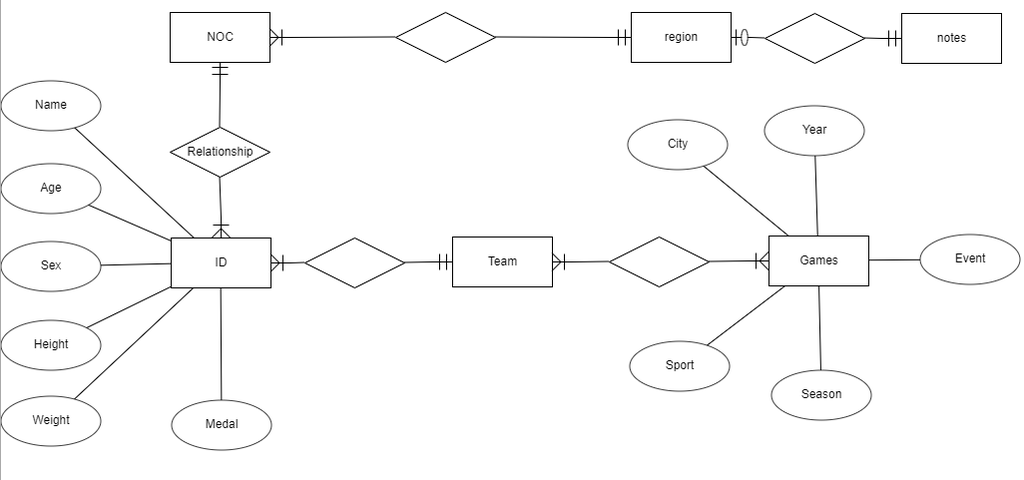

```python
from IPython.display import Image
Image(filename = r"C:\Users\amanta\Documents\Coursera\ERD.png", width = 800, height = 400)
```

#### Entry Deeper Analysis (Performance Winter vs Summer Events)

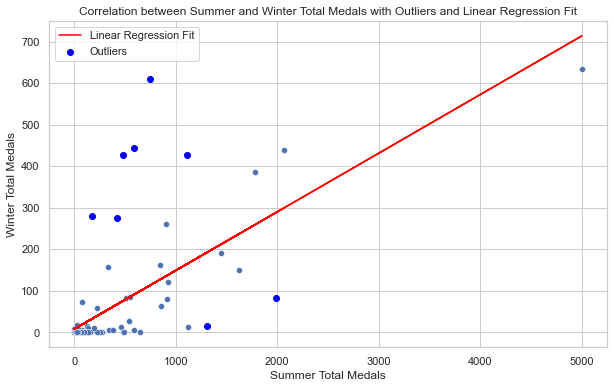

```
Correlation Coefficient: 0.7005179556904234
```

Country with Around 5000 Summer Medals: Country: USA Summer Medals: 5002.0 Winter Medals: 635.0

#### Deeper Analysis (Performance vs Age)

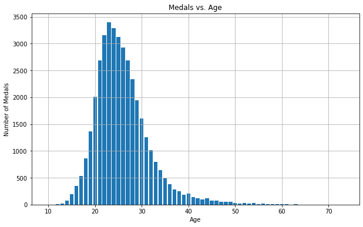

```
           EventGroup  Correlation
```

0 Speed Skating 0.002114 1 Cross Country -0.018487 2 Ice Hockey 0.013334 3 Art Competitions -0.049586 4 Alpine Skiing -0.012798 5 Water Polo 0.084946 6 Sailing Mixed -0.034536 7 Equestrianism Mixed -0.053136 8 Shooting Mixed 0.010006 9 Modern Pentathlon 0.023183 10 Figure Skating 0.016688 11 Synchronized Swimming 0.142025 12 Table Tennis -0.131537 13 Nordic Combined 0.151451 14 Rhythmic Gymnastics -0.131599 15 Freestyle Skiing -0.029311 16 Rugby Sevens -0.032574 17 Biathlon Mixed 0.511759 18 Beach Volleyball 0.053426 19 Ski Jumping -0.042966 20 Badminton Mixed -0.325163 21 Tennis Mixed 0.074267 22 Short Track -0.040403 23 Luge Mixed -0.292947 24 Motorboating Mixed NaN 25 Military Ski 0.181735 26 Croquet Mixed -0.436288 27 Jeu De -0.500000 28 Alpinism Mixed NaN 29 Basque Pelota NaN 30 Aeronautics Mixed NaN

Positive Correlation: Event groups with positive correlation values (e.g., Speed Skating, Ice Hockey, Water Polo, Modern Pentathlon, etc.) indicate a slight positive relationship between the age of athletes and their chances of winning medals. This suggests that older athletes in these event groups may have a slightly higher likelihood of winning medals.

Negative Correlation: Event groups with negative correlation values (e.g., Cross Country, Art Competitions, Alpine Skiing, Sailing Mixed, Equestrianism Mixed, Table Tennis, Rhythmic Gymnastics, etc.) suggest a negative relationship between age and medal performance. This implies that younger athletes in these event groups might have a better chance of winning medals.

No Correlation: In some cases where the correlation value is close to 0 or NaN (like Alpinism Mixed, Basque Pelota, Aeronautics Mixed, etc.), it suggests that there is no significant linear relationship between age and medal performance in those event groups.

#### Deeper Analysis (Diversity)

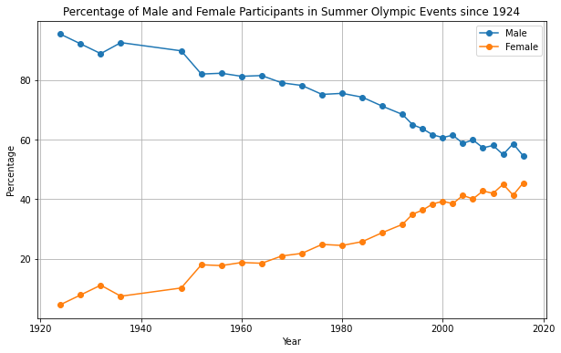

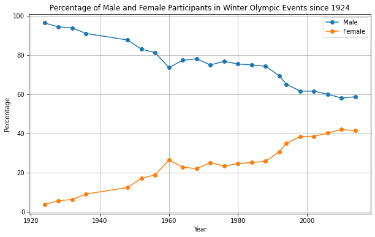

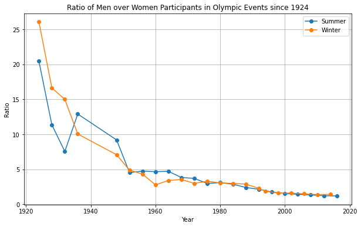

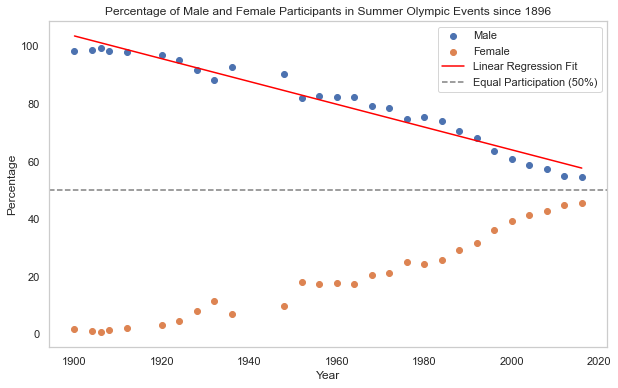

[output not shown]

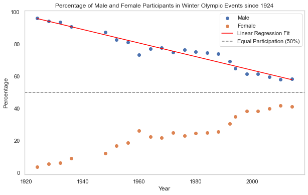

```
R-squared value for Winter events: 0.9498287782760846
Predicted Year when Male and Female Participation will be Equal for Winter events: 2032
```

```
Top 10 Countries with the Biggest Gap in Male and Female Participation (Last 50 Years, Summer Events):
                   region  Percentage_M  Percentage_F  Percentage_Difference
NOC
KUW                Kuwait     98.561151      1.438849              97.122302
KSA          Saudi Arabia     97.685185      2.314815              95.370370
QAT                 Qatar     96.354167      3.645833              92.708333
IRQ                  Iraq     95.833333      4.166667              91.666667
PAK              Pakistan     95.510204      4.489796              91.020408
UAE  United Arab Emirates     95.138889      4.861111              90.277778
OMA                  Oman     93.939394      6.060606              87.878788
BOT              Botswana     92.222222      7.777778              84.444444
IRI                  Iran     92.081448      7.918552              84.162896
ZAM                Zambia     90.604027      9.395973              81.208054
Top 10 Countries with the Biggest Gap in Male and Female Participation (Last 50 Years, Winter Events):
           region  Percentage_M  Percentage_F  Percentage_Difference
NOC
SMR    San Marino     97.297297      2.702703              94.594595
PUR   Puerto Rico     94.594595      5.405405              89.189189
TPE        Taiwan     94.318182      5.681818              88.636364
LUX    Luxembourg     93.750000      6.250000              87.500000
HKG         China      8.333333     91.666667              83.333333
MGL      Mongolia     87.719298     12.280702              75.438596
MEX        Mexico     87.692308     12.307692              75.384615
IRI          Iran     87.500000     12.500000              75.000000
RSA  South Africa     85.714286     14.285714              71.428571
POR      Portugal     85.000000     15.000000              70.000000
```

#### Final Findings

- **Q1: Is there any correlation between the performance of a country in winter Olympics and that in summer Olympics?**

  > It seems that there is a correlation between the performance of a country in winter and summer events. This might indicate that countries with strong sporting infrastructures, training facilities, and resources tend to perform well in both Winter and Summer Olympics. This consistency could be attributed to a comprehensive approach to athlete development.
- **Q2: Does performance change with age?**